### Лаба 4.

```python
import pandas as pd
import numpy as np
import matplotlib.pyplot as plt
import seaborn as sns
%matplotlib notebook

sns.set(style="darkgrid")
```

#### 1) проверка правильной работы алгоритма:

```
1. Получить распределение температуры вдоль стержня на момент времени Т = 0.1, используя следующие параметры:
        k = 1 (коэффициент температуропроводности)
        h = 0.02 (шаг по пространству)
        dt = 0.0002 (шаг по времени)
2. Посчитать значения температуры в 11-ти точках длиной 0,1 включая начало (0, 0.1, 0.2, ..., 1)\
3. Сравнить полученные значения с точным решением:
```

Напишем функцию, вычисляющее точное решение, для проверки алгоритма.

```python
def uxt(x, t):
    if t == 0:
        return 1
    if x == 0 or x == 1:
        return 0
    C = 4 / np.pi

    m = 0
    S = 0
    while m <= 100000:
        M = 2 * m + 1
        sin = np.sin(np.pi * M * x)
        m += 1
        exp = np.exp(-(np.pi ** 2) * (M ** 2) * t)
        S += (exp / M) * sin
    S *= C
    return S
```

```python
true_res = []
xs = [0.0, 0.1, 0.2, 0.3, 0.4, 0.5, 0.6, 0.7, 0.8, 0.9, 1.0]
for x in xs:
    t = 0.1
    true_res.append(uxt(x, t))
    print("x = ", x, "\t t = ", t, "\t U(x, t) = ", uxt(x, t))
```

```
x =  0.0 	 t =  0.1 	 U(x, t) =  0
x =  0.1 	 t =  0.1 	 U(x, t) =  0.14669053961152148
x =  0.2 	 t =  0.1 	 U(x, t) =  0.27898736736437474
x =  0.3 	 t =  0.1 	 U(x, t) =  0.38393426978914724
x =  0.4 	 t =  0.1 	 U(x, t) =  0.451285787289997
x =  0.5 	 t =  0.1 	 U(x, t) =  0.47448746037974915
x =  0.6 	 t =  0.1 	 U(x, t) =  0.4512857872899971
x =  0.7 	 t =  0.1 	 U(x, t) =  0.38393426978914724
x =  0.8 	 t =  0.1 	 U(x, t) =  0.2789873673643748
x =  0.9 	 t =  0.1 	 U(x, t) =  0.14669053961152154
x =  1.0 	 t =  0.1 	 U(x, t) =  0
```

Это точные значения, теперь сравним их с результатом вывода программы:

1) 1 поток

```python
res = []
test = list(map(float, np.array(open('1_result_rank0', 'r').read().split('\n'))[-2].split('\t')[:-1]))
res.extend(test)
res.append(0)
res
```

```
[0.0,
 0.146466,
 0.277883,
 0.38111,
 0.445345,
 0.464316,
 0.436023,
 0.363217,
 0.253545,
 0.117858,
 0]
```

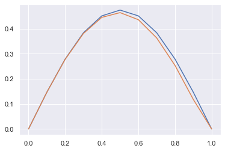

```python
plt.plot(xs, true_res)
plt.plot(xs, res)
plt.show()
```

1) 4 потока

```python
res = []
for i in range(0, 4):
    test = list(map(float, np.array(open('4_result_rank' + str(i), 'r').read().split('\n'))[-2].split('\t')[:-1]))
    res.extend(test)
res
```

```
[0.0,
 0.146466,
 0.277883,
 0.323205,
 0.411949,
 0.458592,
 0.464316,
 0.445345,
 0.38111,
 0.344009,
 0.227996,
 0.088855]
```

Важный момент!!

У нас есть условие, что $\frac{k * dt}{dx^{2}} < 1$, в условии было написано, что берем k = 1, для первого пункта это сработало, для этого уже нет. Поэтому в программе теперь подбирается k, подходящее для задачи:

$$k * \frac{dt}{dx^2} = 0.01$$

Так как, например при 2000 точках и k = 1, мы получим : $\frac{0.0002}{25 * 10^{8}} = 800 > 1$

2к точек

Elapsed time for 1 threads = 0.350712

Elapsed time for 2 threads = 0.369125

Elapsed time for 4 threads = 0.61252

Elapsed time for 8 threads = 1.3888

Elapsed time for 16 threads = 3.63166

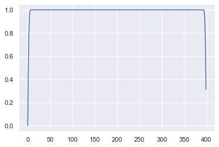

```python
# для 1 треда
arr = list(map(float, np.array(open('good2k/Prog2v2_1_Rank0', 'r').read().split('\t'))[:-1]))
plt.plot(range(len(arr)), arr)
```

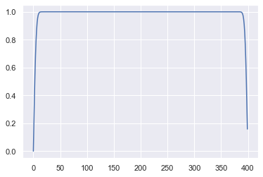

```python
# для 4
res = []
for i in range(0, 4):
    test = list(map(float, np.array(open('good2k/Prog2v2_4_Rank' + str(i), 'r').read().split('\t'))[:-1]))
    res.extend(test)
plt.plot(range(len(res)), res)
```

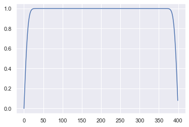

```python
# для 16
res = []
for i in range(0, 16):
    test = list(map(float, np.array(open('good2k/Prog2v2_16_Rank' + str(i), 'r').read().split('\t'))[:-1]))
    res.extend(test)
plt.plot(range(len(res)), res)
```

10к точек

Elapsed time for 1 threads = 1.14695

Elapsed time for 2 threads = 1.19427

Elapsed time for 4 threads = 2.13476

Elapsed time for 8 threads = 5.17799

Elapsed time for 16 threads = 9.30657

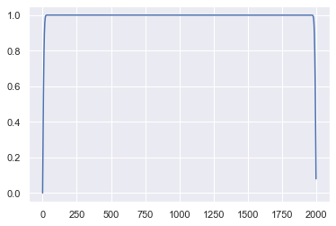

```python
# для 16
res = []
for i in range(0, 16):
    test = list(map(float, np.array(open('good10k/Prog2v2_16_Rank' + str(i), 'r').read().split('\t'))[:-1]))
    res.extend(test)
plt.plot(range(len(res)), res)
```

50к точек

Elapsed time for 1 threads = 0.671834

Elapsed time for 2 threads = 0.677811

Elapsed time for 4 threads = 1.10359

Elapsed time for 8 threads = 2.25343

Elapsed time for 16 threads = 4.42111

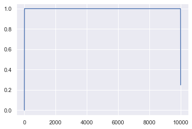

```python
# для 16
res = []
for i in range(0, 16):
    test = list(map(float, np.array(open('good50k/Prog2v2_16_Rank' + str(i), 'r').read().split('\t'))[:-1]))
    res.extend(test)
plt.plot(range(len(res)), res)
```